# Caracterização do desenvolvimento de bibliotecas multiplataforma

Daniel Moreira, Rodrigo Rocha

August 31, 2017

# Comparacao de series temporais originais e com agrupamento com janelas de tempo deslizante

### Allegro

#### Análise temporal

#### QP - A equipe de desenvolvimento de bibliotecas multiplataforma tende a tornar-se mais generalista ou especialista ao longo do tempo?

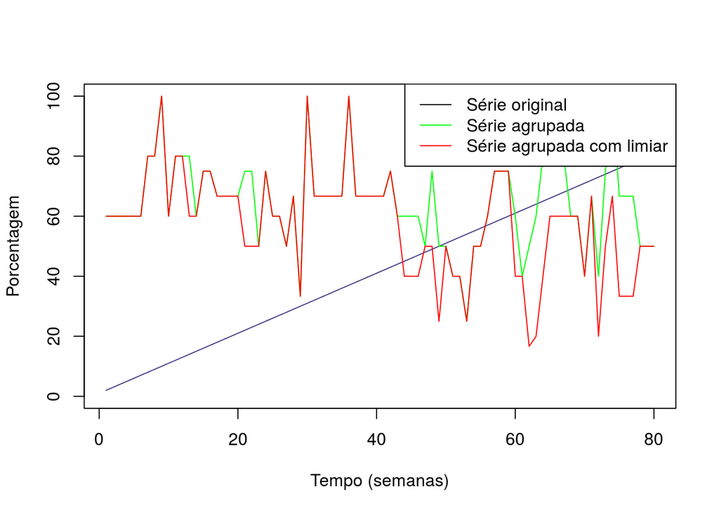

#### Análise temporal

#### QP - Os desenvolvedores de bibliotecas multiplataforma tendem a especializar-se em dispositivos desktop ou mobile ao longo do tempo?

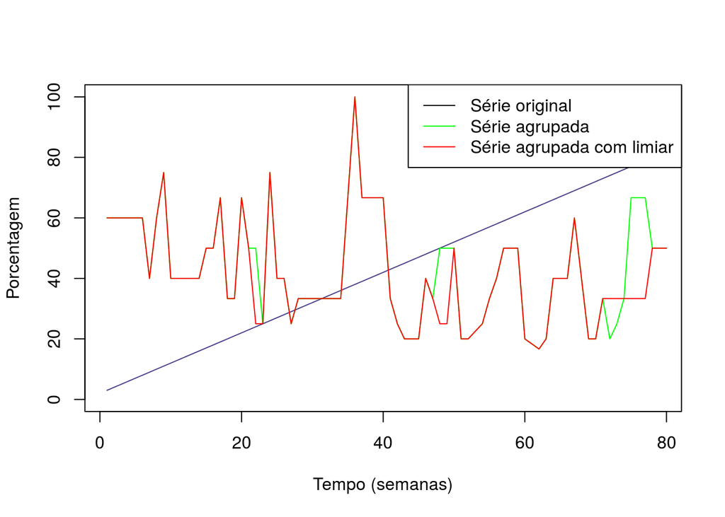

### SDL

#### Análise temporal

#### QP - A equipe de desenvolvimento de bibliotecas multiplataforma tende a tornar-se mais generalista ou especialista ao longo do tempo?

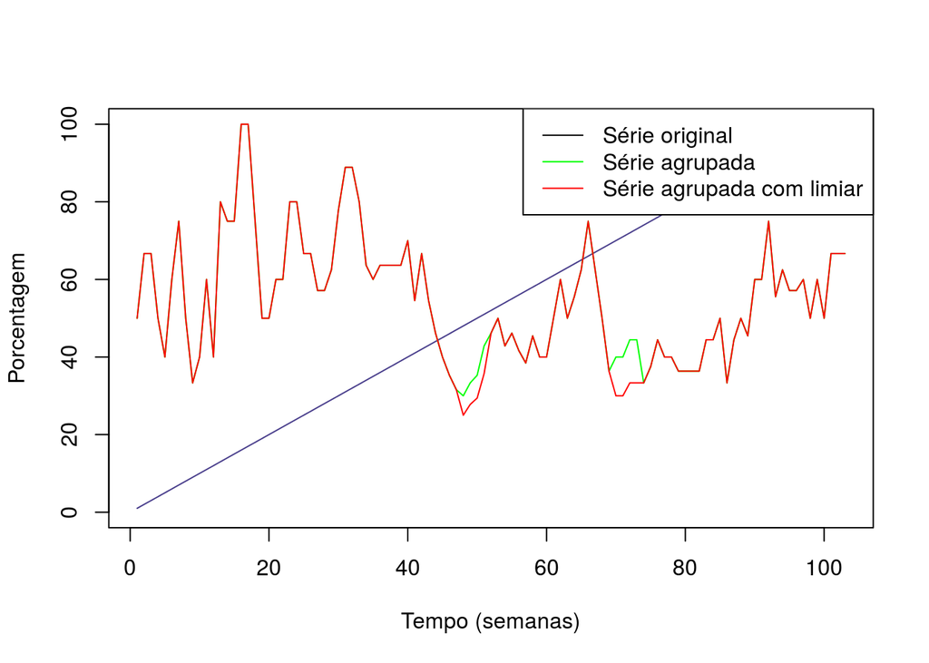

#### Análise temporal

#### QP - Os desenvolvedores de bibliotecas multiplataforma tendem a especializar-se em dispositivos desktop ou mobile ao longo do tempo?

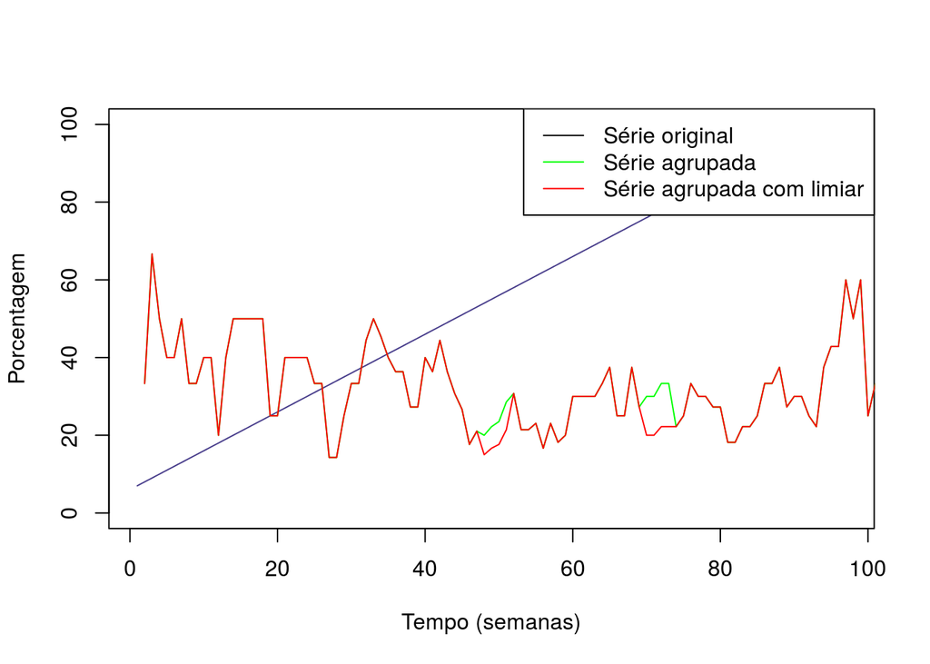

### SFML

#### Análise temporal

#### QP - A equipe de desenvolvimento de bibliotecas multiplataforma tende a tornar-se mais generalista ou especialista ao longo do tempo?

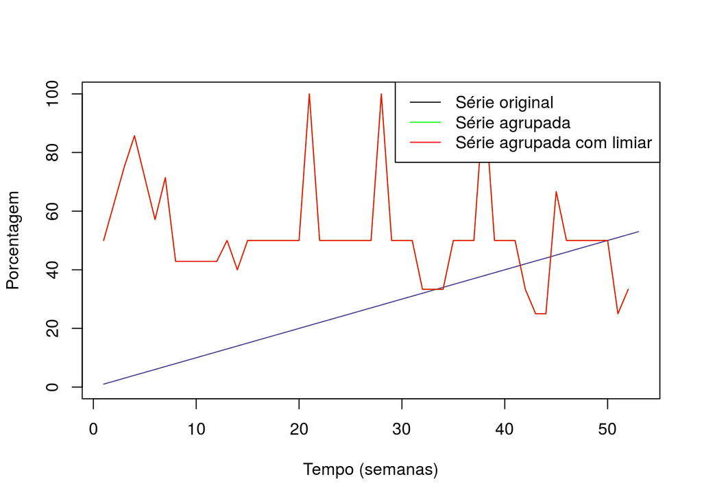

#### Análise temporal

#### QP - Os desenvolvedores de bibliotecas multiplataforma tendem a especializar-se em dispositivos desktop ou mobile ao longo do tempo?

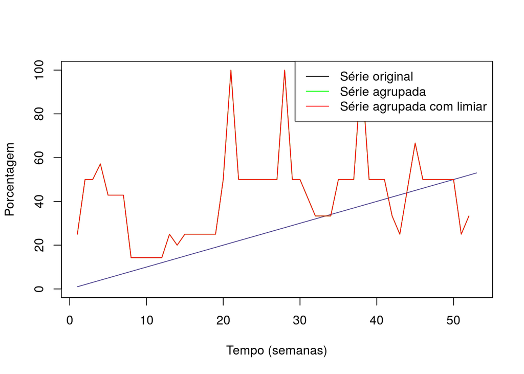

### Cocos2d-x

#### Análise temporal

#### QP - A equipe de desenvolvimento de bibliotecas multiplataforma tende a tornar-se mais generalista ou especialista ao longo do tempo?

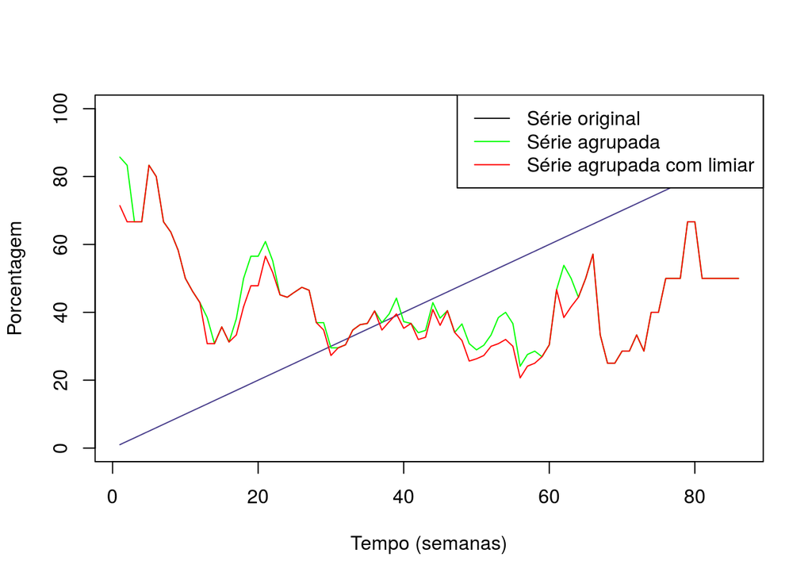

#### Análise temporal

#### QP - Os desenvolvedores de bibliotecas multiplataforma tendem a especializar-se em dispositivos desktop ou mobile ao longo do tempo?

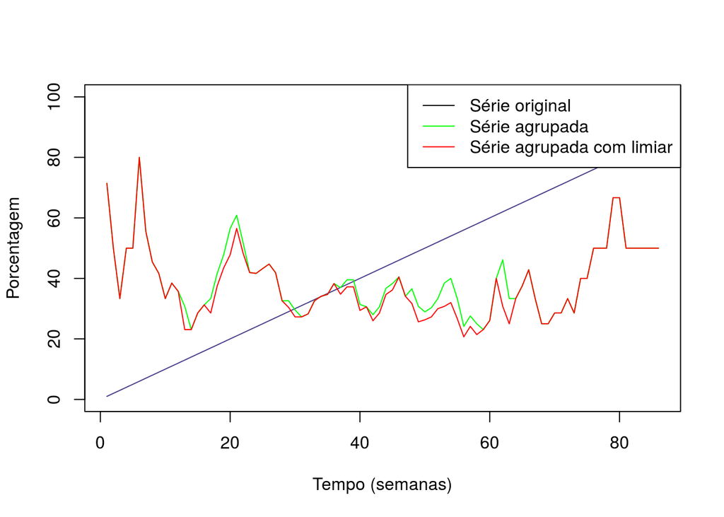

### Godot

#### Análise temporal

#### QP - A equipe de desenvolvimento de bibliotecas multiplataforma tende a tornar-se mais generalista ou especialista ao longo do tempo?

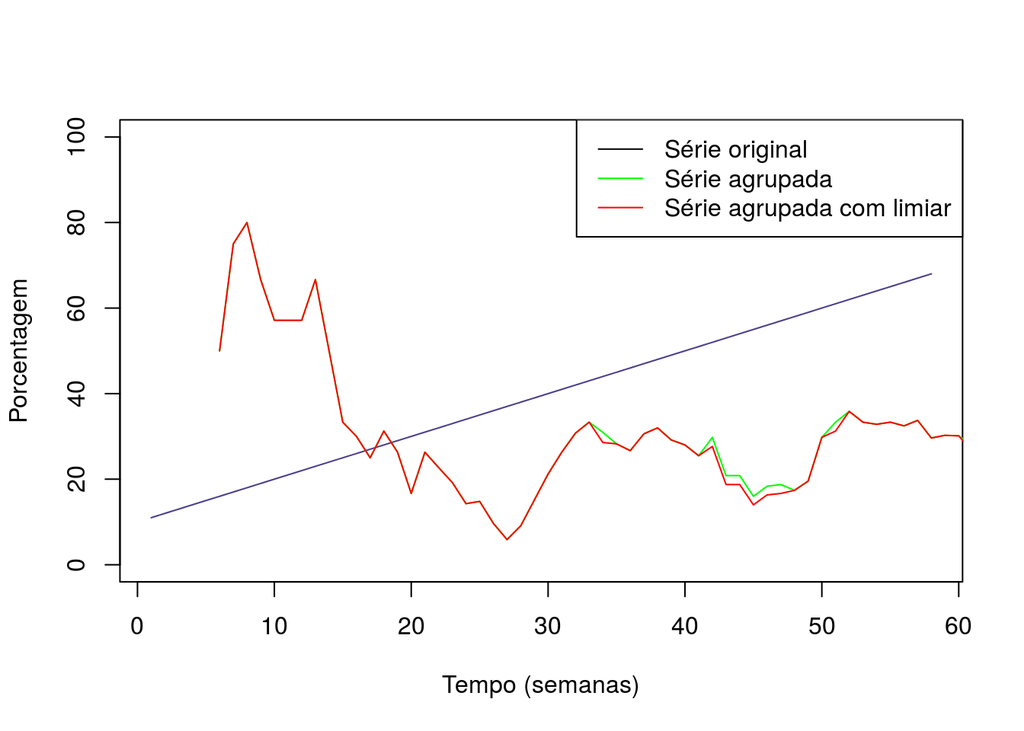

#### Análise temporal

#### QP - Os desenvolvedores de bibliotecas multiplataforma tendem a especializar-se em dispositivos desktop ou mobile ao longo do tempo?

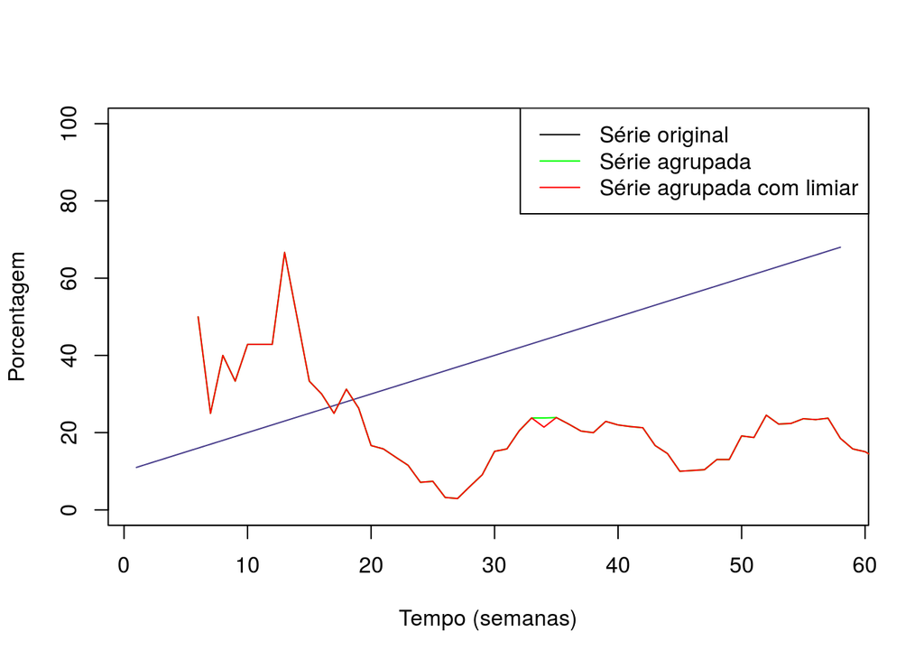